# Johnny Lowe

### Cleaning the dates

After taking a look at the dates, it looks like we have mixed dates from when the complaint was first filed. To keep everything consistent, we decided to remove CMPLNT_TO_DT and CMPLNT_FR_DT observations before 2019. Moreover, since we are interested in when the complaint happened, we will be looking into the CMPLNT_FR_DT and have created attributes separating the year, month, day, and weekday.

```python
# Making the dates datetime objects.
df['CMPLNT_FR_DT'] = pd.to_datetime(df['CMPLNT_FR_DT'], errors='coerce')
df['CMPLNT_TO_DT'] = pd.to_datetime(df['CMPLNT_TO_DT'])
df['RPT_DT'] = pd.to_datetime(df['RPT_DT'])
df = df[~(df[‘CMPLNT_FR_DT’] < ‘2019-01-01’) & ~(df[‘CMPLNT_TO_DT’] < ‘2019-01-01’)] # Removing dates before 2019 in both CMPLNT_FR_DT and CMPLNT_TO_DT
```

```python
# Creating the new date features to separate the year, month, day, and weekday.
df['CMPLNT_FR_YEAR'] = pd.DatetimeIndex(df["CMPLNT_FR_DT"]).year
df['CMPLNT_FR_MONTH'] = pd.DatetimeIndex(df["CMPLNT_FR_DT"]).month
df['CMPLNT_FR_DAY'] = pd.DatetimeIndex(df["CMPLNT_FR_DT"]).day
df['CMPLNT_FR_WEEKDAY'] = pd.DatetimeIndex(df["CMPLNT_FR_DT"]).weekday
```

```python
#df['CMPLNT_FR_YEAR'] = df['CMPLNT_FR_YEAR'].astype(int) #Changing year type to int instead of flaot.
```

```python
df['CMPLNT_FR_YEAR'].value_counts()
```

```
2022.0    247908
2021.0      7368
2020.0       596
2019.0       188
Name: CMPLNT_FR_YEAR, dtype: int64
```

```python
df["CMPLNT_TO_TM"].replace(r'^\s*$', np.nan, regex=True, inplace=True)
#df['CMPLNT_TO_TM'].fillna("ONGOING", inplace=True)
```

```python
df['DIFF_REPORTED_ACTUAL_DT'] = abs((df['RPT_DT'] - df['CMPLNT_FR_DT']))
```

```python
df['DIFF_REPORTED_ACTUAL_DT'].value_counts()
```

```
0 days       167465
1 days        39015
2 days         9287
3 days         5664
4 days         3708
              ...
508 days          1
636 days          1
847 days          1
1069 days         1
803 days          1
Name: DIFF_REPORTED_ACTUAL_DT, Length: 855, dtype: int64
```

```python
df.isnull().sum()/len(df) * 100
```

```
CMPLNT_NUM                   0.000000
ADDR_PCT_CD                  0.000000
BORO_NM                      0.000000
CMPLNT_FR_DT                 0.001562
CMPLNT_FR_TM                 0.000000
CMPLNT_TO_DT                 7.527806
CMPLNT_TO_TM                 7.505936
CRM_ATPT_CPTD_CD             0.000000
HADEVELOPT                   0.000000
HOUSING_PSA                 93.392667
JURISDICTION_CODE            0.000000
JURIS_DESC                   0.000000
KY_CD                        0.000000
LAW_CAT_CD                   0.000000
LOC_OF_OCCUR_DESC            0.000000
OFNS_DESC                    0.000000
PARKS_NM                     0.000000
PATROL_BORO                  0.000000
PD_CD                        0.102709
PD_DESC                      0.000000
PREM_TYP_DESC                0.000000
RPT_DT                       0.000000
STATION_NAME                 0.000000
SUSP_AGE_GROUP               0.000000
SUSP_RACE                    0.000000
SUSP_SEX                     0.000000
TRANSIT_DISTRICT            97.772432
VIC_AGE_GROUP                0.000000
VIC_RACE                     0.000000
VIC_SEX                      0.000000
X_COORD_CD                   0.000000
Y_COORD_CD                   0.000000
Latitude                     0.000000
Longitude                    0.000000
Lat_Lon                      0.000000
New Georeferenced Column     0.000000
PREM_TYPE                    0.000000
CMPLNT_FR_YEAR               0.001562
CMPLNT_FR_MONTH              0.001562
CMPLNT_FR_DAY                0.001562
CMPLNT_FR_WEEKDAY            0.001562
DIFF_REPORTED_ACTUAL_DT      0.001562
dtype: float64
```

```python
df.drop(['HOUSING_PSA', 'TRANSIT_DISTRICT', 'HADEVELOPT'], axis=1, inplace=True)
df.dropna(subset=['PD_CD'],axis=0, inplace=True)
```

```python
df["BORO_NM"].replace("(null)", np.nan,inplace=True) # RePLACING (NULL) with nans to remove these rows.
```

```python
df.dropna(subset=['CMPLNT_FR_DT', 'CMPLNT_FR_YEAR', 'CMPLNT_FR_MONTH', 'CMPLNT_FR_DAY', 'CMPLNT_FR_WEEKDAY', 'BORO_NM'], axis=0, inplace=True)
```

```python
df.isnull().sum()/len(df) * 100
```

```
CMPLNT_NUM                  0.000000
ADDR_PCT_CD                 0.000000
BORO_NM                     0.000000
CMPLNT_FR_DT                0.000000
CMPLNT_FR_TM                0.000000
CMPLNT_TO_DT                7.337599
CMPLNT_TO_TM                7.315669
CRM_ATPT_CPTD_CD            0.000000
JURISDICTION_CODE           0.000000
JURIS_DESC                  0.000000
KY_CD                       0.000000
LAW_CAT_CD                  0.000000
LOC_OF_OCCUR_DESC           0.000000
OFNS_DESC                   0.000000
PARKS_NM                    0.000000
PATROL_BORO                 0.000000
PD_CD                       0.000000
PD_DESC                     0.000000
PREM_TYP_DESC               0.000000
RPT_DT                      0.000000
STATION_NAME                0.000000
SUSP_AGE_GROUP              0.000000
SUSP_RACE                   0.000000
SUSP_SEX                    0.000000
VIC_AGE_GROUP               0.000000
VIC_RACE                    0.000000
VIC_SEX                     0.000000
X_COORD_CD                  0.000000
Y_COORD_CD                  0.000000
Latitude                    0.000000
Longitude                   0.000000
Lat_Lon                     0.000000
New Georeferenced Column    0.000000
PREM_TYPE                   0.000000
CMPLNT_FR_YEAR              0.000000
CMPLNT_FR_MONTH             0.000000
CMPLNT_FR_DAY               0.000000
CMPLNT_FR_WEEKDAY           0.000000
DIFF_REPORTED_ACTUAL_DT     0.000000
dtype: float64
```

```python
df['OFNS_DESC'].value_counts()
```

```
PETIT LARCENY                           54731
HARRASSMENT 2                           40875
ASSAULT 3 & RELATED OFFENSES            27450
GRAND LARCENY                           24449
CRIMINAL MISCHIEF & RELATED OF          22942
FELONY ASSAULT                          12489
OFF. AGNST PUB ORD SENSBLTY &            9453
ROBBERY                                  8150
MISCELLANEOUS PENAL LAW                  7863
BURGLARY                                 7584
GRAND LARCENY OF MOTOR VEHICLE           6385
VEHICLE AND TRAFFIC LAWS                 4155
DANGEROUS DRUGS                          4045
SEX CRIMES                               3472
OFFENSES AGAINST PUBLIC ADMINI           3318
DANGEROUS WEAPONS                        3203
FORGERY                                  3185
THEFT-FRAUD                              1649
OFFENSES INVOLVING FRAUD                 1543
INTOXICATED & IMPAIRED DRIVING           1360
CRIMINAL TRESPASS                        1236
FRAUDS                                    860
POSSESSION OF STOLEN PROPERTY             789
RAPE                                      723
UNAUTHORIZED USE OF A VEHICLE             704
OFFENSES AGAINST THE PERSON               571
ADMINISTRATIVE CODE                       443
OTHER OFFENSES RELATED TO THEF            324
ARSON                                     324
NYS LAWS-UNCLASSIFIED FELONY              220
OTHER STATE LAWS (NON PENAL LA            166
BURGLAR'S TOOLS                           138
OFFENSES AGAINST PUBLIC SAFETY             76
THEFT OF SERVICES                          73
KIDNAPPING & RELATED OFFENSES              65
PETIT LARCENY OF MOTOR VEHICLE             59
AGRICULTURE & MRKTS LAW-UNCLASSIFIED       58
GAMBLING                                   55
FRAUDULENT ACCOSTING                       30
PROSTITUTION & RELATED OFFENSES            20
ENDAN WELFARE INCOMP                       19
ALCOHOLIC BEVERAGE CONTROL LAW             14
DISORDERLY CONDUCT                         11
CHILD ABANDONMENT/NON SUPPORT              11
OTHER STATE LAWS                            8
OFFENSES RELATED TO CHILDREN                8
(null)                                      6
HOMICIDE-NEGLIGENT,UNCLASSIFIE              6
NYS LAWS-UNCLASSIFIED VIOLATION             5
JOSTLING                                    5
LOITERING/GAMBLING (CARDS, DIC              5
KIDNAPPING                                  4
FELONY SEX CRIMES                           4
ANTICIPATORY OFFENSES                       3
UNLAWFUL POSS. WEAP. ON SCHOOL              3
INTOXICATED/IMPAIRED DRIVING                3
HOMICIDE-NEGLIGENT-VEHICLE                  2
DISRUPTION OF A RELIGIOUS SERV              2
ESCAPE 3                                    2
Name: OFNS_DESC, dtype: int64
```

### Cleaning up the age groups of the victims and suspects.

It seems like there were 50,569 observations where the suspect's age group was (null); therefore, we will replace those values with "UNKNOWN" to be consistent with the 'UNKNOWN' category. Furthermore, it looks like both the SUSP_AGE_GROUP and VIC_AGE_GROUP cotained various non-sensical age groups and we decided to drop those rows and only keep rows with defined age groups.

```python
df['OFNS_DESC'].replace('(null)', 'UNKNOWN', inplace=True)
```

## Creating binary categories for violent vs NON_VIOLENT crimes

```python
VIOLENT_VICTIM_CRIME = ["ASSAULT 3 & RELATED OFFENSES", "FELONY ASSAULT", "ROBBERY","BURGLARY","SEX CRIMES", "OFFENSES AGAINST PUBLIC ADMINI",
                        "DANGEROUS WEAPONS", "INTOXICATED & IMPAIRED DRIVING", "RAPE", "OFFENSES AGAINST THE PERSON", "ARSON", "OTHER OFFENSES RELATED TO THEF",
                        "MURDER & NON-NEGL. MANSLAUGHTER", "NYS LAWS-UNCLASSIFIED FELONY", "OFFENSES AGAINST PUBLIC SAFETY", "KIDNAPPING & RELATED OFFENSES",
                        "FRAUDULENT ACCOSTING", "ENDAN WELFARE INCOMP", "DISORDERLY CONDUCT", "OFFENSES RELATED TO CHILDREN", "HOMICIDE-NEGLIGENT,UNCLASSIFIE",
                        "JOSTLING", "KIDNAPPING", "FELONY SEX CRIMES", "UNLAWFUL POSS. WEAP. ON SCHOOL", "INTOXICATED/IMPAIRED DRIVING", "HOMICIDE-NEGLIGENT-VEHICLE",
                        "DISRUPTION OF A RELIGIOUS SERV"]
NON_VIOLENT = ["PETIT LARCENY", "HARRASSMENT 2", "GRAND LARCENY", "CRIMINAL MISCHIEF & RELATED OF", "OFF. AGNST PUB ORD SENSBLTY &",
               "MISCELLANEOUS PENAL LAW", "GRAND LARCENY OF MOTOR VEHICLE", "VEHICLE AND TRAFFIC LAWS", "DANGEROUS DRUGS", "FORGERY", "THEFT-FRAUD"
               "OFFENSES INVOLVING FRAUD", "FRAUDS", "CRIMINAL TRESPASS", "POSSESSION OF STOLEN PROPERTY", "UNAUTHORIZED USE OF A VEHICLE",
               "ADMINISTRATIVE CODE", "OTHER STATE LAWS (NON PENAL LA", "BURGLAR'S TOOLS", "THEFT OF SERVICES", "PETIT LARCENY OF MOTOR VEHICLE",
               "AGRICULTURE & MRKTS LAW-UNCLASSIFIED", "GAMBLING", "PROSTITUTION & RELATED OFFENSES", "ALCOHOLIC BEVERAGE CONTROL LAW",
               "CHILD ABANDONMENT/NON SUPPORT", "OTHER STATE LAWS", "NYS LAWS-UNCLASSIFIED VIOLATION", "LOITERING/GAMBLING (CARDS, DIC",
               "ANTICIPATORY OFFENSES", "ESCAPE 3"]
df[“CRIME_TYPE”] = np.where(df[“OFNS_DESC”].isin(VIOLENT_VICTIM_CRIME), ‘VIOLENT’, ‘NON-VIOLENT’)
```

```python
df[["OFNS_DESC", "CRIME_TYPE"]]
```

|  | OFNS_DESC | CRIME_TYPE |
| --- | --- | --- |
| 1 | ROBBERY | VIOLENT |
| 2 | HARRASSMENT 2 | NON-VIOLENT |
| 3 | RAPE | VIOLENT |
| 4 | ROBBERY | VIOLENT |
| 5 | THEFT-FRAUD | NON-VIOLENT |
| ... | ... | ... |
| 256792 | ASSAULT 3 & RELATED OFFENSES | VIOLENT |
| 256793 | FRAUDS | NON-VIOLENT |
| 256794 | VEHICLE AND TRAFFIC LAWS | NON-VIOLENT |
| 256795 | HARRASSMENT 2 | NON-VIOLENT |
| 256796 | SEX CRIMES | VIOLENT |

255356 rows × 2 columns

```python
df['SUSP_AGE_GROUP'].replace('(null)', 'UNKNOWN', inplace=True) # Replacing the (null) value for age group with UNKNOWN
df = df[df['SUSP_AGE_GROUP'].isin(['UNKNOWN', '25-44', '45-64', '18-24', '<18', '65+'])]
```

```python
df['SUSP_AGE_GROUP'].value_counts()
```

```
UNKNOWN    146887
25-44       63388
45-64       21848
18-24       15974
<18          4886
65+          2355
Name: SUSP_AGE_GROUP, dtype: int64
```

```python
df = df[df['VIC_AGE_GROUP'].isin(['UNKNOWN', '25-44', '45-64', '18-24', '<18', '65+'])]
df['VIC_AGE_GROUP'].value_counts()
```

```
25-44      90469
UNKNOWN    72602
45-64      48530
18-24      21484
65+        12465
<18         9773
Name: VIC_AGE_GROUP, dtype: int64
```

### Cleaning up SUSP_RACE and VIC_RACE.

It looks like they both contain the (null) value that we have decided to replace as UNKNOWN as we did in the SUSP_AGE_GROUP attribute

```python
df['SUSP_RACE'].replace('(null)', 'UNKNOWN', inplace=True)
df['SUSP_RACE'].value_counts()
```

```
UNKNOWN                           112889
BLACK                              73317
WHITE HISPANIC                     32748
WHITE                              18687
BLACK HISPANIC                     10155
ASIAN / PACIFIC ISLANDER            7093
AMERICAN INDIAN/ALASKAN NATIVE       434
Name: SUSP_RACE, dtype: int64
```

```python
df['VIC_RACE'].replace('(null)', 'UNKNOWN', inplace=True)
df['VIC_RACE'].value_counts()
```

```
UNKNOWN                           77472
BLACK                             63958
WHITE HISPANIC                    44999
WHITE                             36867
ASIAN / PACIFIC ISLANDER          20526
BLACK HISPANIC                    10586
AMERICAN INDIAN/ALASKAN NATIVE      915
Name: VIC_RACE, dtype: int64
```

### Cleaning up SUSP_SEX and VIC_SEX

It looks like these features have the same problem and we will be renaming the (null) class as UNKNOWN. Furthermore, we are assuming that U stands for UNKNOWN and we will be labeling the U values as UNKNOWN for consistency.

```python
df['SUSP_SEX'].replace('(null)', 'UNKNOWN', inplace=True)
df['SUSP_SEX'].replace('U', 'UNKNOWN', inplace=True)
df['SUSP_SEX'].value_counts()
```

```
M          120057
UNKNOWN    102568
F           32698
Name: SUSP_SEX, dtype: int64
```

```python
df[["CMPLNT_TO_DT"]].isnull().sum()
```

```
CMPLNT_TO_DT    18736
dtype: int64
```

### NOTE - Meaning of Labels for Victim Sex

- D - Business/Organization victim
- E - PSNY/People of the State of New York

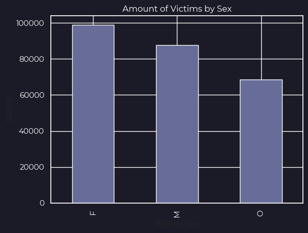

```python
df["VIC_SEX"].replace("D", "O", inplace=True)
df["VIC_SEX"].replace("E", "O", inplace=True)
custom_params = {'figure.facecolor':'#1a1b26', 'text.color': 'white', 'xtick.color': 'white',
 'ytick.color': 'white'}
sns.set_theme(font="Montserrat", rc=custom_params)
df["VIC_SEX"].value_counts().plot(kind="bar", xlabel="Victim Sex", ylabel="Count", color="#686c98").set(title="Amount of Victims by Sex", facecolor='#1a1b26');
```

```python
pd.crosstab(df["VIC_SEX"], df["CRIME_TYPE"], values=df[(df["DIFF_REPORTED_ACTUAL_DT"] > pd.Timedelta("0 days")) & (df["DIFF_REPORTED_ACTUAL_DT"] <= pd.Timedelta("31 days"))]["DIFF_REPORTED_ACTUAL_DT"], aggfunc='mean')
```

| CRIME_TYPE VIC_SEX | NON-VIOLENT | VIOLENT |
| --- | --- | --- |
| F | 4 days 17:56:14.923823496 | 3 days 21:27:17.581395348 |
| M | 4 days 07:28:52.591237974 | 2 days 23:39:05.122669283 |
| O | 4 days 20:43:00.492060722 | 3 days 02:00:37.361008154 |

```python
from sklearn.linear_model import LogisticRegression
from sklearn.model_selection import train_test_split
from sklearn.metrics import accuracy_score, confusion_matrix, roc_curve, auc
from sklearn.preprocessing import StandardScaler
import calendar
```

```python
df['CMPLNT_FR_MONTH'] = df['CMPLNT_FR_MONTH'].astype(int)
df['CMPLNT_FR_WEEKDAY'] = df['CMPLNT_FR_WEEKDAY'].astype(int)
```

```python
df['Month'] = df['CMPLNT_FR_MONTH'].apply(lambda x: calendar.month_abbr[x])
df['WeekDay'] = df['CMPLNT_FR_WEEKDAY'].apply(lambda x: calendar.day_name[x])
```

```python
#df['Month'].value_counts().plot(kind="bar", title="Criminal Complaints by Month");
```

```python
#df['WeekDay'].value_counts().plot(kind="bar", title="Criminal Complaints by Weekday");
```

```python
cat_features = pd.get_dummies(df[['SUSP_AGE_GROUP', 'SUSP_RACE', 'SUSP_SEX', 'VIC_AGE_GROUP', 'VIC_RACE', 'VIC_SEX','Month', 'WeekDay']])
num_features = df[['Latitude', 'Longitude']]
features = cat_features.join(num_features)
target = ‘CRIME_TYPE’
```

```python
X = features
y = df['CRIME_TYPE']
X_train, X_test, y_train, y_test = train_test_split(X, y, test_size=0.20, random_state=10202022)
```

```python
model = LogisticRegression(random_state=10202022)
model.fit(X_train, y_train)
```

```
LogisticRegression(random_state=10202022)
```

```python
len(features.columns)
```

```
53
```

```python
np.exp(model.coef_)
```

```
array([[1.23243616, 1.0748862 , 0.95973724, 0.93443384, 1.12287112,
        0.74885318, 0.97420399, 1.18676867, 1.1601382 , 1.12255815,
        0.73822962, 0.79062718, 1.13672825, 0.9937786 , 1.33810424,
        0.75123329, 1.16087295, 0.87001516, 0.6757639 , 0.48606691,
        3.1428613 , 0.95813484, 0.96433288, 0.92740045, 1.04916022,
        1.1735848 , 1.0253645 , 0.77835639, 1.13670315, 1.13203602,
        1.68835981, 0.52267191, 1.11096156, 0.95706018, 0.70298595,
        1.12610888, 1.08364909, 0.98271656, 1.19982971, 1.08470153,
        1.12250369, 0.84441179, 0.92443134, 0.97729475, 0.98029833,
        0.94089406, 1.16940236, 1.17710625, 0.94557485, 0.9285579 ,
        0.89612973, 1.39901273, 1.21906914]])
```

```python
coefficients = pd.DataFrame(np.transpose(np.exp(model.coef_)), features.columns, columns=['Odds'])
scores = pd.DataFrame(np.transpose(model.coef_), features.columns, columns=['Scores'])
```

```python
scores_sorted = scores['Scores'].sort_values(ascending=False)
```

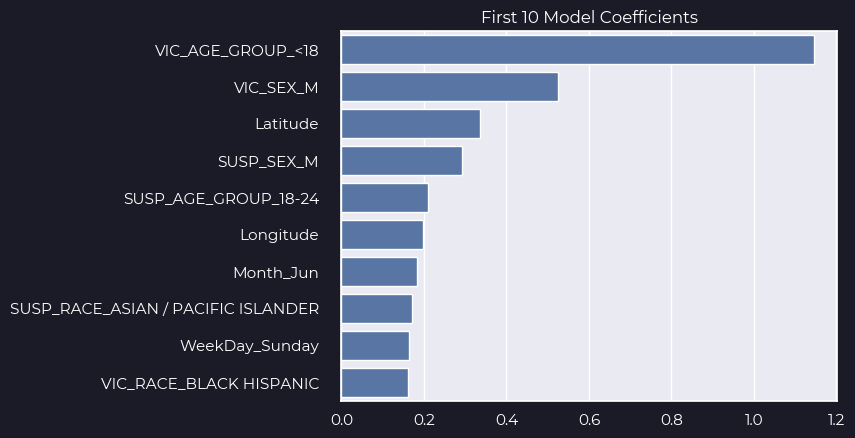

```python
sns.barplot(y=scores_sorted.head(10).index, x=scores_sorted.head(10).values, color="b");
plt.title("First 10 Model Coefficients");
plt.tick_params(axis='y', which='both', pad=10)
```

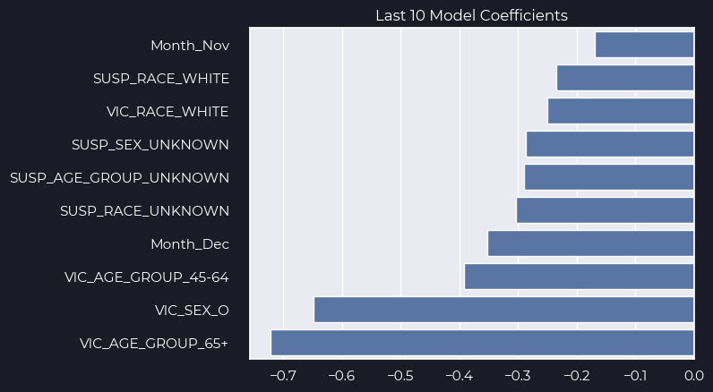

```python
sns.barplot(y=scores_sorted.tail(10).index, x=scores_sorted.tail(10).values, color="b");
plt.title("Last 10 Model Coefficients");
plt.tick_params(axis='y', which='both', pad=10)
```

```python
coefficients.sort_values(by="Odds", ascending=False).iloc[:20]
```

|  | Odds |
| --- | --- |
| VIC_AGE_GROUP_<18 | 3.142861 |
| VIC_SEX_M | 1.688360 |
| Latitude | 1.399013 |
| SUSP_SEX_M | 1.338104 |
| SUSP_AGE_GROUP_18-24 | 1.232436 |
| Longitude | 1.219069 |
| Month_Jun | 1.199830 |
| SUSP_RACE_ASIAN / PACIFIC ISLANDER | 1.186769 |
| WeekDay_Sunday | 1.177106 |
| VIC_RACE_BLACK HISPANIC | 1.173585 |
| WeekDay_Saturday | 1.169402 |
| VIC_AGE_GROUP_18-24 | 1.160873 |
| SUSP_RACE_BLACK | 1.160138 |
| SUSP_RACE_WHITE HISPANIC | 1.136728 |
| VIC_RACE_WHITE HISPANIC | 1.136703 |
| VIC_SEX_F | 1.132036 |
| Month_Feb | 1.126109 |
| SUSP_AGE_GROUP_<18 | 1.122871 |
| SUSP_RACE_BLACK HISPANIC | 1.122558 |
| Month_May | 1.122504 |

```python
print(f'Coefficients: {model.coef_}')
print(f'Intercept: {model.intercept_}')
```

```
Coefficients: [[ 0.20899283  0.07221479 -0.04109574 -0.06781446  0.1158889  -0.28921233
  -0.02613456  0.17123421  0.14853913  0.11561014 -0.30350036 -0.23492875
   0.12815418 -0.00624083  0.29125387 -0.28603904  0.14917227 -0.13924464
  -0.39191153 -0.72140898  1.14513363 -0.04276676 -0.03631873 -0.07536982
   0.04799005  0.160063    0.02504816 -0.25057077  0.1281321   0.1240178
   0.52375753 -0.64880133  0.10522591 -0.043889   -0.35241837  0.11876822
   0.08033413 -0.01743454  0.18217964  0.08130486  0.11556163 -0.16911499
  -0.0785765  -0.02296698 -0.01989834 -0.06092473  0.15649282  0.1630591
  -0.05596223 -0.07412254 -0.10967008  0.3357668   0.19808757]]
Intercept: [-0.00102679]
```

```python
preds = model.predict(X_test)
```

```python
accuracy = accuracy_score(y_test, preds)
```

```python
confusion = confusion_matrix(y_test, preds)
```

```python
confusion
```

```
array([[35610,  1624],
       [11380,  2451]], dtype=int64)
```

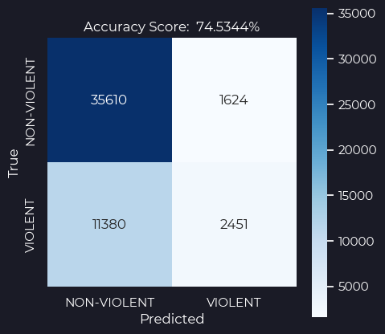

```python
plt.figure(figsize=(5,5))
hm = sns.heatmap(confusion, fmt='d',annot=True, square = True, cmap = 'Blues', xticklabels=['NON-VIOLENT', 'VIOLENT'], yticklabels=['NON-VIOLENT', 'VIOLENT']);
hm.set(title=f'Accuracy Score: {accuracy*100: .4f}%');
hm.set_xlabel('Predicted', color="white");
hm.set_ylabel("True", color="white");
```

```python
probs = model.predict_proba(X_test)[:,1]
```

```python
fpr, tpr, thresholds = roc_curve(y_test, probs, pos_label="VIOLENT")
```

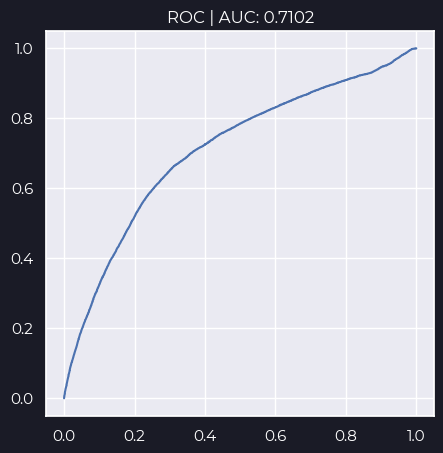

```python
plt.figure(figsize=(5,5))
plt.plot(fpr, tpr, label='Logistic Regression (area = %0.2f)');
plt.title(f"ROC | AUC: {round(auc(fpr, tpr), 4)}");
```

## Feature Selection

```python
from sklearn.feature_selection import RFE
rfe = RFE(model, n_features_to_select= None)
rfe = rfe.fit(X_train, y_train)
print(rfe.support_)
print(rfe.ranking_)
```

```
[ True  True False False  True  True False  True  True  True  True  True
  True False  True  True  True False  True  True  True False False False
 False False False  True False  True  True  True False False  True False
 False False False False False  True False False False False  True  True
 False False False  True  True]
[ 1  1 16 14  1  1 20  1  1  1  1  1  1 28  1  1  1 10  1  1  1 26 22 23
 12  2 24  1 11  1  1  1  6 15  1  4  8 27  3  7  5  1  9 21 25 18  1  1
 19 17 13  1  1]
```

```python
X_train_df = pd.DataFrame(X_train)
features_selected = X_train_df.columns[rfe.support_]
corr = X_train_df[X_train_df.columns[rfe.support_]].corr()
```

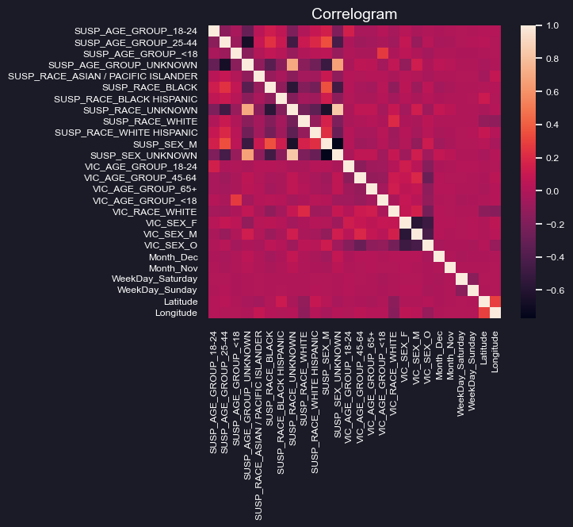

```python
custom_params = {'figure.facecolor':'#1a1b26', 'text.color': 'white', 'xtick.color': 'white',
 'ytick.color': 'white'}
sns.set_theme(rc=custom_params, font_scale=0.8)
sns.heatmap(corr, square=True);
plt.title("Correlogram", fontsize=14);
```

## Refitting model with optimal features set.

```python
model2 = LogisticRegression(random_state=10202022)
model2.fit(X_train_df[X_train_df.columns[rfe.support_]], y_train)
```

```
LogisticRegression(random_state=10202022)
```

```python
X_test_df = pd.DataFrame(X_test)
preds2 = model2.predict(X_test_df[X_train_df.columns[rfe.support_]])
```

```python
model2.coef_
```

```
array([[ 0.27578167,  0.14912725,  0.15440987, -0.23662731,  0.10516053,
         0.13445381,  0.14843526, -0.29611671, -0.23189269,  0.17158512,
         0.27440792, -0.27232495,  0.3237723 , -0.25596697, -0.52525805,
         1.23373857, -0.2740568 ,  0.10974976,  0.47992383, -0.59099855,
        -0.37727458, -0.18216403,  0.20166772,  0.20789029,  0.35628902,
         0.21023191]])
```

```python
coefficients2 = pd.DataFrame(np.transpose(np.exp(model2.coef_)), X_train_df.columns[rfe.support_], columns=['Odds'])
```

```python
coefficients2.sort_values(by="Odds", ascending=False)
```

|  | Odds |
| --- | --- |
| VIC_AGE_GROUP_<18 | 3.434044 |
| VIC_SEX_M | 1.615951 |
| Latitude | 1.428020 |
| VIC_AGE_GROUP_18-24 | 1.382333 |
| SUSP_AGE_GROUP_18-24 | 1.317560 |
| SUSP_SEX_M | 1.315751 |
| Longitude | 1.233964 |
| WeekDay_Sunday | 1.231078 |
| WeekDay_Saturday | 1.223441 |
| SUSP_RACE_WHITE HISPANIC | 1.187185 |
| SUSP_AGE_GROUP_<18 | 1.166969 |
| SUSP_AGE_GROUP_25-44 | 1.160821 |
| SUSP_RACE_BLACK HISPANIC | 1.160018 |
| SUSP_RACE_BLACK | 1.143912 |
| VIC_SEX_F | 1.115999 |
| SUSP_RACE_ASIAN / PACIFIC ISLANDER | 1.110889 |
| Month_Nov | 0.833465 |
| SUSP_RACE_WHITE | 0.793031 |
| SUSP_AGE_GROUP_UNKNOWN | 0.789285 |
| VIC_AGE_GROUP_45-64 | 0.774168 |
| SUSP_SEX_UNKNOWN | 0.761607 |
| VIC_RACE_WHITE | 0.760289 |
| SUSP_RACE_UNKNOWN | 0.743701 |
| Month_Dec | 0.685728 |
| VIC_AGE_GROUP_65+ | 0.591403 |
| VIC_SEX_O | 0.553774 |

```python
X_train_df.columns[rfe.support_]
```

```
Index(['SUSP_AGE_GROUP_18-24', 'SUSP_AGE_GROUP_25-44', 'SUSP_AGE_GROUP_<18',
       'SUSP_AGE_GROUP_UNKNOWN', 'SUSP_RACE_ASIAN / PACIFIC ISLANDER',
       'SUSP_RACE_BLACK', 'SUSP_RACE_BLACK HISPANIC', 'SUSP_RACE_UNKNOWN',
       'SUSP_RACE_WHITE', 'SUSP_RACE_WHITE HISPANIC', 'SUSP_SEX_M',
       'SUSP_SEX_UNKNOWN', 'VIC_AGE_GROUP_18-24', 'VIC_AGE_GROUP_45-64',
       'VIC_AGE_GROUP_65+', 'VIC_AGE_GROUP_<18', 'VIC_RACE_WHITE', 'VIC_SEX_F',
       'VIC_SEX_M', 'VIC_SEX_O', 'Month_Dec', 'Month_Nov', 'WeekDay_Saturday',
       'WeekDay_Sunday', 'Latitude', 'Longitude'],
      dtype='object')
```

```python
len(X_train_df.columns[rfe.support_])
```

```
26
```

```python
acc2 = accuracy_score(y_test, preds2)
```

```python
confusion2 = confusion_matrix(y_test, preds2)
```

```python
confusion2
```

```
array([[35685,  1549],
       [11529,  2302]], dtype=int64)
```

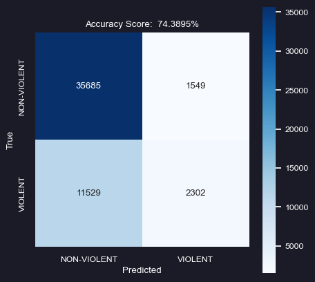

```python
plt.figure(figsize=(5,5))
hm = sns.heatmap(confusion2, fmt='d',annot=True, square = True, cmap = 'Blues', xticklabels=['NON-VIOLENT', 'VIOLENT'], yticklabels=['NON-VIOLENT', 'VIOLENT']);
hm.set(title=f'Accuracy Score: {acc2*100: .4f}%');
hm.set_xlabel('Predicted', color="white");
hm.set_ylabel("True", color="white");
```

```python
probs2 = model2.predict_proba(X_test[X_test.columns[rfe.support_]])[:,1]
```

```python
fpr2, tpr2, thresholds2 = roc_curve(y_test, probs2, pos_label="VIOLENT")
```

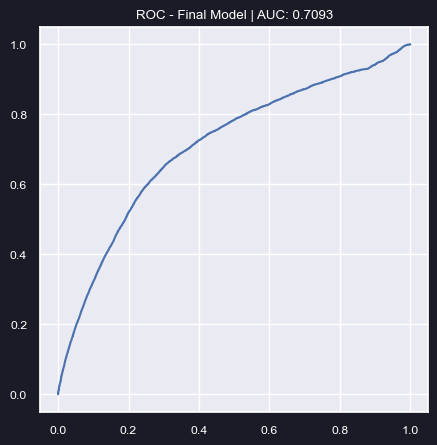

```python
plt.figure(figsize=(5,5))
plt.plot(fpr2, tpr2, label='Logistic Regression (area = %0.2f)');
plt.title(f"ROC - Final Model | AUC: {round(auc(fpr2, tpr2), 4)}");
```